Master's Thesis · ISEG · 2024 / 2026

# BTC Direction Prediction Using KANs Within the AFML Framework

A leakage-free benchmark of six models, with closed-form symbolic formula extraction from a Kolmogorov-Arnold Network.

**Petr Terletskiy** · l63023

Master's in Mathematical Finance

ISEG · Universidade de Lisboa

Contents Overview

## Table of Contents

01

Problems & Solutions

Four problems from the crypto-ML literature, mapped to four contributions.

02

KAN Theoretical Background

Kolmogorov-Arnold representation theorem, B-splines, and why KANs need less data.

03

Methodology

Pre-CPCV, CPCV pipeline, Post-CPCV. From raw OHLCV to closed-form formula.

04

Results

Six-model comparison; equity curves and bet sizing; symbolic expression for P(Up).

05

Limitations & Next Steps

Honest limitations and the future-work direction each one frames.

06

Conclusion

AFML and symbolic extraction successfully implemented; market efficiency confirmed.

Part 01 · Problems & Solutions 3 / 21

## Four problems, four contributions

P1

Leaky 85-95% accuracy claims

Crypto-ML literature uses K-fold CV that leaks future returns; no correction for selection bias.

→

C1

Full AFML under CPCV

CUSUM, TBL, sample weights, purged CV, DSR / PBO / DeLong corrections.

P2

Single-family feature sets

BTC studies pick TA *or* macro *or* on-chain; cross-family signal never tested.

→

C2

73-feature cross-family universe

TA, math, macro, on-chain, lag, all competing under one multi-model MDA cap.

P3

KAN untested on crypto direction

The newest deep architecture has no leakage-free benchmark on BTC direction.

→

C3

Six-model benchmark

KAN vs. AR Logistic, Logistic, RF, XGBoost, LSTM under identical splits, features, weights.

P4

Deep models stay black boxes

No published work extracts a closed-form formula for crypto direction from a trained net.

→

C4

Closed-form P(Up)

Symbolic expression extracted from the trained KAN via Algorithm 1 (Wu et al., 2024).

Part 02 · KAN Theoretical Background 4 / 21

## Kolmogorov-Arnold Networks · the theoretical foundation

Representation theorem (1957)

Kolmogorov and Arnold proved that **any continuous multivariate function on a bounded domain can be written as a finite sum of univariate functions**:

Kolmogorov-Arnold f(x<sub>1</sub>, …, x<sub>n</sub>) = Σ<sub>q</sub> Φ<sub>q</sub>( Σ<sub>p</sub> φ<sub>q,p</sub>(x<sub>p</sub>) )

From theorem to network (Liu et al., 2024)

- **A learnable univariate function on every edge**, parameterised as a B-spline.
- Each edge carries a flexible 1D curve, not a single scalar weight.
- Nodes just sum the activated outputs.

[figure not shown]

Why KANs for this problem

- **Fewer parameters than MLPs** · matters for the 1,168-event sample.
- **Symbolifiable by construction** · each 1D edge curve maps to a closed-form primitive.
- **Validated on weak-signal finance** · VIX (Wu et al., 2024), KASPER stock prediction.

Part 03 · Methodology 5 / 21

## Pipeline overview · three phases

Phase I

Pre-CPCV

From raw OHLCV to `(X, y, w, t1)`

1. **1 ·** Data Loading
2. **2 ·** Daily Volatility (EWMA)
3. **3 ·** CUSUM Filter
4. **4 ·** Triple-Barrier Labels
5. **5 ·** Sample Weights
6. **6 ·** Feature Engineering
7. **7 ·** Data Alignment

→

Phase II

CPCV Pipeline

28 splits · 7 paths · 6 models · 5 seeds

1. **8 ·** CPCV Split Generation
2. **9 ·** Per-Fold Preproc · FFD & Robust Scaler
3. **10 ·** Per-Fold Preproc · Multi-Model MDA
4. **11 ·** Hyperparameter Tuning
5. **12 ·** Model Training
6. **13 ·** Calibration

→

Phase III

Post-CPCV

Evaluation & closed-form formula

1. **14 ·** Evaluation Metrics  
   ML · Financial · AFML
2. **15 ·** Symbolic Extraction  
   PyKAN · Algorithm 1

Phase I output

X

y

w

t1

Phase I · Step 01-02 6 / 21

## Data Loading & EWMA Volatility

Data Loading

**Source:** BTC-USD via `yfinance`.

**Type:** daily OHLCV bars.

**Date range:** November 1, 2014 to May 10, 2026 (about 4,200 daily bars).

**Why daily.** Daily resolution matches the economic horizon of the macro and on-chain features. Higher frequencies inject microstructure noise that overwhelms signal at this horizon.

Daily Volatility · EWMA

Exponentially-weighted standard deviation of log returns, with span 50:

EWMA volatility σ<sub>t</sub> = √( EWMA<sub>span=50</sub>[ r<sub>t</sub><sup>2</sup> ] )

**Why span 50.** López de Prado's default for equities is 100; BTC's regime cycle is shorter, so 50 reacts faster to volatility shifts without becoming jumpy.

**Two downstream uses of σ<sub>t</sub>:**

1. Sets the **CUSUM threshold** (next slide).
2. Sets the **profit-take and stop-loss barriers** in triple-barrier labeling.

One volatility estimate, two roles. This couples sampling and labeling to the prevailing market regime.

Phase I output

X

y

w

t1

Phase I · Step 03-04 7 / 21

## CUSUM Filter & Triple-Barrier Labels

CUSUM Filter

s<sub>t</sub><sup>+</sup> = max(0, s<sub>t-1</sub><sup>+</sup> + r<sub>t</sub> − E[r])  
s<sub>t</sub><sup>−</sup> = min(0, s<sub>t-1</sub><sup>−</sup> + r<sub>t</sub> − E[r])

**Trigger:** |s<sub>t</sub><sup>±</sup>| ≥ h · σ<sub>t</sub>, **h = 1.0**

Fire an event when accumulated drift exceeds one daily-volatility unit; reset that accumulator and continue. Events fire from **2015-08-08** onward (Ethereum's Frontier launch, the first day with valid `eth_btc_ratio` data). Yields **1,168 events** after the rare-label drop.

[figure not shown]

Triple-Barrier Labels

From each CUSUM event, watch the next bars until one of three barriers is touched:

- **Take-profit** (pt = 1.5 · σ<sub>t</sub>) → label `+1`
- **Stop-loss** (sl = 1.5 · σ<sub>t</sub>) → label `−1`
- **Vertical barrier** (num_days = 10) → sign of the return, or `0` if |return| < **0.02** (the `MIN_RETURN` floor)

The first barrier touched wins. **t1** records the touch time. Residual class-0 events are then dropped via `drop_rare_labels(min_pct=0.085)`, leaving binary `{−1, +1}` labels.

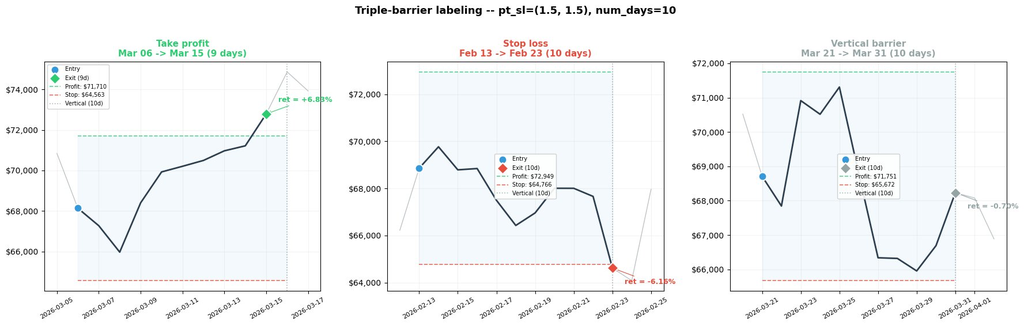

Phase I output

X

y

w

t1

Phase I · Step 05 8 / 21

## Sample Weights · three reasons not every event counts equally

W1

### Return magnitude

It does not make sense to treat a day with a +9% return the same as a day with a +1% return. Both might earn the same label `+1`, but the +9% event carries more information about how strong the signal is.

**Component:** weight scales with |r<sub>event</sub>|.

W2

### Label uniqueness

When two events overlap in time, the bars between them are double-counted: both labels depend on the same returns. Treating overlapping events as fully independent inflates the effective sample size and lets the model fit noise.

**Component:** weight scales with how unique each event's labelling window is.

W3

### Time decay

Today's BTC market is institutionally dominated, with deeper liquidity and ETF flows. Older periods reflect a smaller, retail-driven market. Recent data is closer to the regime we are forecasting into.

**Component:** linear time decay, **oldest = 40% of newest** (`time_decay_factor = 0.4`).

**Final weight:** w<sub>i</sub> = uniqueness<sub>i</sub> × |r<sub>i</sub>| × decay<sub>i</sub>, capped at the 99th percentile and normalized to mean 1. The weights are honored by every model's loss function during training.

Phase I output

X

y

w

t1

Phase I · Step 06 9 / 21

Family

What it captures

Count

**Technical**

- Momentum, trend, mean-reversion
- Volume confirmation
- Volatility estimators

**25**

**Mathematical · AFML Part 4**

- Information theory (entropy, complexity)
- Fractality and persistence (Hurst, variance ratio)
- Structural-break detection (SADF, SMT)

**9**

**Macro**

- Risk-on / risk-off context (VIX, DXY, equity returns)
- US treasury yields and curves
- Commodities at 14d + 30d horizons

**20**

**Crypto-macro**

- Within-crypto relative-value signal (ETH/BTC)

**1**

**On-chain**

- Network activity (addresses, tx count, hash rate)
- Holder behaviour (MVRV, exchange flow, supply %)
- Miner economics (fee per tx, BTC issuance)

**8**

**Lag**

- Autoregressive memory
- Log returns at `[1, 2, 3, 4, 5, 6, 7, 14, 21, 30]` day lags

**10**

**Total feature universe**

**73**

Phase I output

X

y

w

t1

Phase I · Step 07 10 / 21

## Data Alignment · the package handed to Phase II

X

### Feature matrix (1168 × 73)

y

### Labels (1168,)

Triple-barrier labels in `{ −1, +1 }`. No zero class.

**+1 (Up): 56.85%**  
**−1 (Down): 43.15%**

w

### Sample weights (1168,)

Uniqueness × |r| × time-decay, capped and normalized. Honored by every model's loss function.

t1

### Horizon end times (1168,)

Barrier-touch time for each event. Required by CPCV's purging logic to drop train observations that overlap into the test fold.

=

**irregularly-sampled, event-indexed time series**

Phase II · Step 08 11 / 21

## CPCV Split Generation

Configuration

- **N = 8** time-ordered groups, **k = 2** test groups per split.
- **Splits = C(8, 2) = 28** · **reconstructed paths = 7**.
- **Embargo** = 11 observations after each test group; train observations whose `t1` spans a test group are **purged**.
- Per group: ~146 events · average train fold 858, average test fold 292.

Why CPCV beats walk-forward

**Walk-forward gives one timeline.** One Sharpe number, no variance estimate, no way to tell luck from skill.

**CPCV gives seven.** Each event appears in multiple test folds across paths, yielding seven path-level Sharpe estimates and enough dispersion for a meaningful Probability of Backtest Overfitting.

G1

G2

G3

G4

G5

G6

G7

G8

Split **1** / 28 Test: **G1, G2** · Train: **G3, G4, G5, G6, G7, G8**

Train (6 groups) Test (k = 2 groups) Embargo zone · 11 observations after each test group, dropped from training

Phase II · Step 09-10 12 / 21

## Per-Fold Preprocessing · FFD, Robust Scaler, Multi-Model MDA

FFD & Robust Scaler

**Fractional Differencing (FFD).**

- Order `d ∈ (0, 1)` preserves long-run memory while passing ADF.
- Applied to **ATR only** · the one non-stationary feature flagged in EDA.
- `d*` re-estimated per fold on the training partition.

**Robust Scaler.**

- Median + IQR instead of mean + std.
- Resists BTC fat tails · outliers do not compress the bulk of the distribution.

Both fitted on the train portion of each fold, applied to test.

Multi-Model MDA

**Mean Decrease Accuracy.**

- Shuffle one feature, measure F1 drop.
- Big drop → real signal. No drop → ignored feature.
- AFML default for unbiased importance (López de Prado).

**Why multi-model** · a single voter inherits that model's bias.

- **Logistic Regression** → linear-combination signal.
- **Random Forest** → non-linear-combination signal.

**Aggregation.**

- z-score each importance vector, then average.
- **TOP_K_FRAC = 0.20** → top fifth, ~14–15 features per fold.
- AR Logistic additionally pins its 10 lag columns.

Phase II · Step 11-12 13 / 21

## Six Models & Optuna Tuning

Six model families

M1

### AR Logistic

Econometric baseline. Logistic on the 10 lag features only, selected by name.

M2

### Logistic Regression

Linear ML baseline. Full MDA-selected feature set with L1/L2 tuning.

M3

### Random Forest

Bagged decision trees with sample-weight support.

M4

### XGBoost

Gradient-boosted trees. Benchmark tabular ML method.

M5

### LSTM

Single-layer recurrent net over a 14-day sliding window.

M6

### KAN

Single hidden layer, B-spline edges (the novel architecture).

Optuna TPE + MedianPruner

**TPE** (Tree-structured Parzen Estimator) fits two density models, good past trials and bad, then samples new hyperparameters where the ratio favors the good. **MedianPruner** kills trials early when their running F1 falls below the median of past trials at the same step.

**Tuning is once per split, not per seed.** Per tuned model: **28 splits × 40 trials = 1,120 tuning runs**, then **28 splits × 5 seeds = 140 final-training runs** using the per-split tuned configuration.

Trial 1

KEPT ✓

F1 = 0.61  
completed

Trial 2

PRUNED ×

stopped  
at epoch 5

Trial 3

OK

F1 = 0.52  
completed

Trial 4

KEPT ✓

F1 = 0.59  
completed

Trial 5

PRUNED ×

stopped  
at epoch 3

5 random trials seed TPE → **Trials 6–40** sampled by TPE → Best of 40 per fold

Phase II · Step 13 14 / 21

## Calibration · raw scores → trustable probabilities

Platt scaling · Platt (1999)

### Classical ML

AR Logistic · Logistic Regression · Random Forest · XGBoost

Fits a sigmoid to the 1D log-odds with two free parameters (slope `a`, intercept `b`). Can correct both calibration sharpness and directional bias.

P<sub>cal</sub>(z) = σ(a · z + b)

Vector scaling · Guo et al. (2017)

### Neural networks

LSTM · KAN

Temperature `T` plus per-class bias `b`. The bias `b0` is pinned to zero to break the softmax overparameterisation, so two free parameters fit: `T` and `b1`.

P<sub>cal</sub>(z) = softmax( (z + b) / T ), b<sub>0</sub> ≡ 0

Raw scores

→

Calibrator

→

Calibrated P(Up)

→

S-curve bet sizing · AFML Ch. 10

70 / 15 / 15 partition

Each training fold split chronologically (no shuffling).

- **70% train** — model fit
- **15% validation** — early stopping, best-state tracking
- **15% calibration** — fit Platt or vector scaling

Why vector, not just temperature

Pure temperature scaling preserves the argmax of the logits, so it cannot correct a directional bias. **The per-class bias `b1` lifts that constraint**, fixing both sharpness and direction.

Phase III · Step 14-15 15 / 21

## Evaluation Metrics & Symbolic Extraction

Evaluation metrics · three families

Machine Learning · per fold

- Accuracy
- F1 macro (weighted)
- AUC-ROC
- Log loss
- Brier score
- Confusion matrices (pooled)

Financial · per path

- Annualized Sharpe (7 paths)
- Max drawdown
- Cumulative return
- Win rate, profit factor
- Sortino, Calmar
- Bet-size diagnostics

AFML · statistical correction

- **DSR** (Ch. 14): Sharpe corrected for trials, skew, kurtosis
- Survives at DSR ≥ 0.95
- **PBO** (Ch. 11): IS-best vs. OOS rank
- **DeLong**: pairwise AUC (15 pairs)

Symbolic extraction · Algorithm 1 (Wu et al., 2024)

1. **Train** KAN with sparsity penalties (L1 + entropy).
2. **Prune** edges below threshold; architecture compresses, e.g. `[73, 6, 2]` → `[3, 3, 2]`.
3. **Substitute** each surviving edge with the best-fitting primitive (sin, cos, tanh, polynomial).
4. **Fine-tune** the constants with shapes locked.
5. **Simplify** via SymPy.

Output P(Up) = 1 / (1 + exp(−f(x<sub>1</sub>, x<sub>2</sub>, x<sub>3</sub>)))

Part 04 · Results 16 / 21

## Model Comparison · KAN versus five baselines

| Rank | Model | Median Sharpe | Std Sharpe | 95% CI (low, high) | DSR |
| --- | --- | --- | --- | --- | --- |
| #1 | KAN | 0.5588 | 0.7539 | (−0.4677, 1.1607) | 0.2470 |
| #2 | AR Logistic | 0.3806 | 0.7355 | (−0.0544, 1.2101) | — |
| #3 | LSTM | 0.1541 | 0.6388 | (−0.3902, 0.7032) | — |
| #4 | XGBoost | 0.0493 | 0.5830 | (−0.0638, 0.2514) | — |
| #5 | Random Forest | 0.0287 | 0.7533 | (−0.6165, 0.8834) | — |
| #6 | Logistic Regression | −0.2173 | 1.5969 | (−0.7321, 2.0594) | — |
| ref | **Buy-and-hold** | **2.2722** | 0.5768 | **(1.8903, 2.4685)** | — |

Headline

- **KAN tops trained models**, Sharpe = 0.5588
- **No model crosses DSR ≥ 0.95** (KAN's DSR = 0.2470)
- **Only buy-and-hold has a strictly positive CI** (1.89, 2.47)

DeLong pairwise AUC

- **2 of 15 pairs significant** at α = 0.05
- AR Logistic vs. XGBoost · p = 0.043
- Random Forest vs. XGBoost · p = 0.032
- Neither survives Bonferroni (α/15 = 0.003)

PBO · KAN under selection bias

- **Baseline PBO = 0.6571** · adversarial (> 0.5).
- **KAN leave-one-out PBO = 0.543** (Δ −0.114).
- Excluding KAN lowers selection bias, but the system still flags more than half of selections as biased.

Part 04 · Results 17 / 21

## Equity Curves & Bet Size Distribution

Path-by-path equity per model · 2017–2026

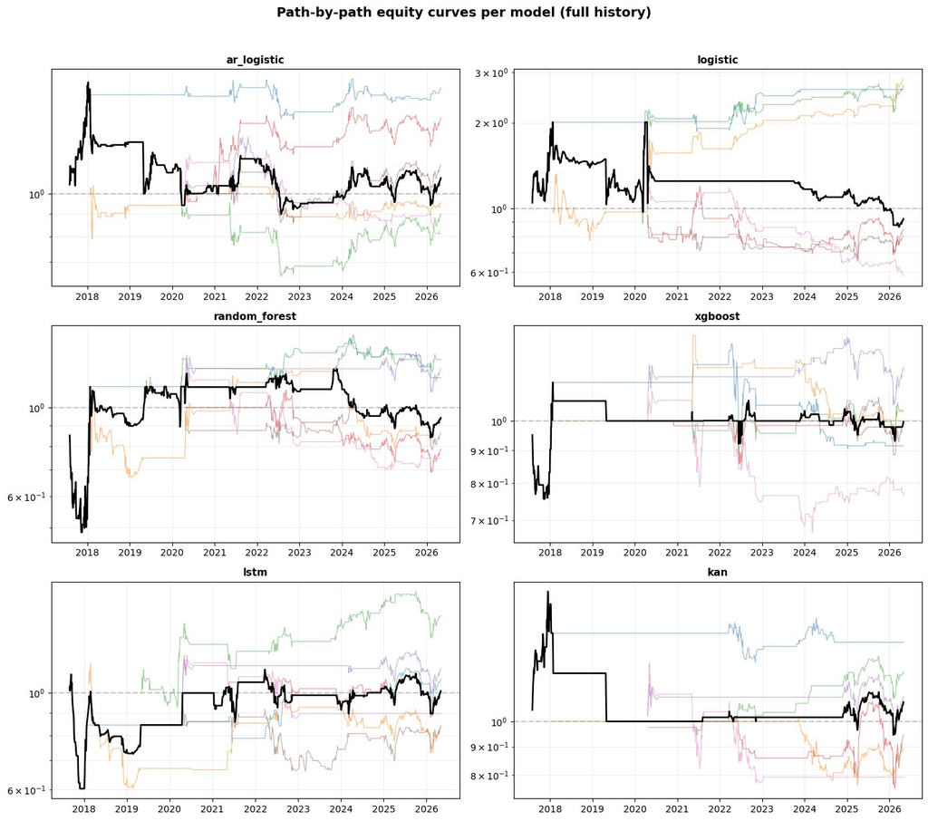

- **Black medians hover near 1.0** for all models; wide path dispersion explains why every trained CI crosses zero.
- **KAN's median sits highest among trained models** in the late window, but still well below buy-and-hold.

Bet-size diagnostics

| Model | Abst. | Mean \|b\| | At cap | Long | Short |
| --- | --- | --- | --- | --- | --- |
| AR Logistic | 50.5% | 0.273 | 0.6% | 81.0% | 19.0% |
| Logistic | 52.6% | 0.287 | 2.8% | 73.3% | 26.7% |
| Random Forest | 54.2% | 0.274 | 1.5% | 81.2% | 18.8% |
| XGBoost | 73.1% | 0.269 | 0.5% | 79.2% | 20.8% |
| LSTM | 53.2% | 0.257 | 0.0% | 84.0% | 16.0% |
| KAN | 70.1% | 0.272 | 0.9% | 89.6% | 10.4% |

3,129 events per model (LSTM: 3,103, due to the 14-day sequence window). **Median |bet| = 0.250** for every model.

- **KAN and XGBoost most cautious** · ~70% abstention.
- **KAN tilts the most long** (89.6%) · catches the BTC uptrend.
- **Almost no model bets at the cap** (under 3%) · calibrated probabilities cluster around moderate confidence.

Part 04 · Results 18 / 21

## Symbolic Expression · the closed-form formula

Architecture & surviving features

**Pruned architecture:** `3 inputs → 3 active → 2 outputs`

**Width vector:** `[[3, 0], [3, 0], [2, 0]]` · sum-only nodes, no multiplicative units.

**Symbolification rate:** **100%** (15 of 15 edges) · every surviving edge replaced with a closed-form primitive.

**Fold:** `fold 27` (deployment-fold candidate).

**Surviving features (top 3 by stability):**

- `eth_btc_ratio` crypto-macro
- `log_returns_lag6` lag · 6-day return
- `natgas_ret_30` macro · natural gas 30d

Accuracy · KAN vs. its own formula

Pre-symbolic: **46.67%**  
Post-symbolic: **51.85%**  
Substitution gap: **+5.18 pp**

P(Up) = 1 / (1 + exp(−f(x)))

where E = eth_btc_ratio, L = log_returns_lag6, N = natgas_ret_30 f(x) = + 3/283 · ( − 284·E/505 − (−1766·L/179 − 1529/843)<sup>4</sup>/1000 − 434·tanh(3217·N/944 + 2141/935)/663 + 4511/913 )<sup>2</sup> − 351/877 · sin( (797/768 − 3716·N/745)<sup>3</sup>/109 − 405·sin(4547·L/949 + 147/754)/508 + 517·cos(2279·E/686 + 4631/899)/687 + 433/74 ) + 197/828 · cos( 10·(797/768 − 3716·N/745)<sup>3</sup>/847 − 625·sin(4547·L/949 + 147/754)/609 + 31·cos(2279·E/686 + 4631/899)/32 + 2734/385 ) + 455/932 · tanh( 235·E/924 + 209·tanh(3217·N/944 + 2141/935)/706 − 4610/959 ) + 11/19

Four primitive-weighted terms (squared polynomial, sin, cos, tanh) plus a constant bias, all on the tanh-normalized inputs. Symbols simplified to E, L, N for display only.

Part 05 · Limitations & Next Steps 19 / 21

## Honest limitations, and the future-work direction each one frames

L1

### Daily resolution discards microstructure

The created features (macro, on-chain) were only available at daily timestamps; no 1h or 4h source exists for them, so daily bars were the only common horizon. Intraday signal is therefore skipped. **Next step:** hourly extension once intraday feeds become available, unlocking order-flow features.

L2

### Sample size capped by daily CUSUM events

1,168 events is small by ML standards and drives the wide CIs. **Next step:** hourly resolution would push the count past 10,000 and tighten every CI.

L3

### Architectural simplifications for symbolifiability

KAN trained with single hidden layer, grid = 3, top 3 features only. **Next step:** test whether richer KANs improve trading performance.

L4

### Computational cost

Optuna was run with limited `n_trials = 40` and simplified parameter dictionaries to keep training tractable across 28 CPCV folds and 6 models. **Next step:** larger search budgets and richer hyper-parameter spaces, especially for KAN and LSTM.

Part 06 · Conclusion 20 / 21

## Conclusion · what the thesis demonstrates

A1

### Full AFML pipeline end-to-end

- CUSUM events + triple-barrier labels
- AFML sample weights + fractional differencing
- CPCV with purging and embargo
- DSR / PBO / DeLong corrections
- One reproducible pipeline; scales to any daily OHLCV asset

A2

### Closed-form symbolic extraction from a CPCV-trained KAN

- Algorithm 1 (Wu et al., 2024) adapted to the weak-signal regime
- Human-readable closed-form expression for P(Up)
- 100% symbolification of surviving edges
- Methodological contribution beyond a standard benchmark study

F1

### BTC direction is essentially efficient

- **No trained model reaches DSR ≥ 0.95**
- 6 of 6 trained-model Sharpe CIs cross zero
- Only buy-and-hold survives the AFML protocol
- 85-95% literature accuracy claims do not replicate
- Structural BTC uptrend is the dominant empirical signal

Bottom line

- Methodologically: rigorous AFML benchmark + novel symbolic extraction.
- Empirically: BTC direction shows no tradable predictability beyond holding the asset.

BTC Direction Prediction · KANs · AFML

Thank you.

Questions?

**Petr Terletskiy** · l63023

Master's in Mathematical Finance · ISEG / Universidade de Lisboa

Supervisor: Prof. João Afonso Bastos

**1** / 23